# Instituto Tecnologico de Costa Rica

> Sede San Carlos  
> Matematica para Ciencia de los Datos  
> Tarea Sesion 2 y 3  
> Autor: Andres Gonzalez  
> 2019

### I Parte

**1.** Ejecute las siguientes instrucciones para practicar el uso algunos comandos de la matemática de R.

**a.** pi*2^3-sqrt(4)

**b.** abs(12-17*2/3-9)

**c.** factorial(4)

**d.** log(2,10)

**e.** log(2)

**f.** exp(0.069314725)

```r
pi*2^3-sqrt(4)
```

```
## [1] 23.13274
```

```r
abs(12-17*2/3-9)
```

```
## [1] 8.333333
```

```r
factorial(4)
```

```
## [1] 24
```

```r
log(2,10)
```

```
## [1] 0.30103
```

```r
log(2)
```

```
## [1] 0.6931472
```

```r
exp(0.069314725)
```

```
## [1] 1.071773
```

**2.** Calcule en R el valor de $x$, sabiendo que $x$

$x = \frac{1+y}{1+2z^{2}}$

$y = 10$

$z = π$

```r
y <- 10
z <- pi
x <- (1+y)/(1+2*z^2)
x
```

```
## [1] 0.5303963
```

**3.** Calcule en R el valor de $z$, sabiendo que $z$

$z = \sqrt{x^{2}+y^{2}}$

```r
x <- -10
y <- pi
z <- sqrt(x^2+y^2)
z
```

```
## [1] 10.48187
```

**4.** Dado $x = (3,−5, 31, −1,−9, 10,0, 18)$ y $y = (1, 1, −3, 1,−99, −10, 10, −7)$ realice lo siguiente:

**a.** Introduzca $x$ e $y$ como vectores de R

```r
x <- c(3,-5,31,-1,-9,10,0,18)
y <- c(1,1,-3,1,-99,-10,10,-7)
```

**b.** Calcule el ángulo entre los vectores $x$ e $y$

```r
prod_punto <- sum(x*y)
norm_x <- sqrt(sum(x^2))
norm_y <- sqrt(sum(y^2))
theta <- acos(prod_punto/(norm_x*norm_y))
theta
```

```
## [1] 1.423855
```

**c.** Extraiga las entradas 2 y 7 del vector $x$

```r
x[c(2,7)]
```

```
## [1] -5  0
```

**d.** Extraiga de $y$ todas las entradas de dicho vector, excepto las posiciones 2 y 7

```r
y[-c(2,7)]
```

```
## [1]   1  -3   1 -99 -10  -7
```

**e.** Escriba un comando en R para extraer las entradas menores que -3 o mayores que 10.

```r
x[x < -3 | x > 10]
```

```
## [1] -5 31 -9 18
```

```r
y[y < -3 | y > 10]
```

```
## [1] -99 -10  -7
```

**f.** Escriba un comando en R para extraer las entradas mayores que 0 y que sean número pares.

```r
x[x > 0 & x %% 2 == 0]
```

```
## [1] 10 18
```

```r
y[y > 0 & y %% 2 == 0]
```

```
## [1] 10
```

### II Parte

**1.** Ejecute el siguiente código:

```r
v = c(1,3)
print(v)
```

```
## [1] 1 3
```

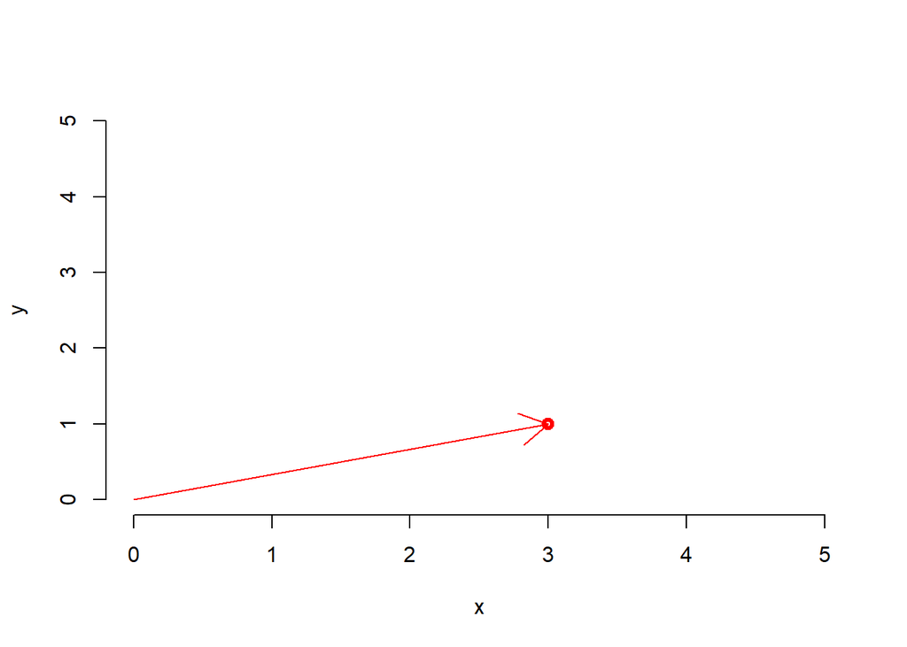

```r
plot(3,1, xlim=c(0,5), ylim=c(0,5), xlab="x", ylab="y", lwd=3, col='red', bty='n')
arrows(0,0,3,1,col='red')
```

**2.** Ejecute el siguiente código y explique según lo estudiado en clase: ¿Cuáles fueron los dos vectores base para diseñar la figura?, ¿Qué significa el vector de color verde?

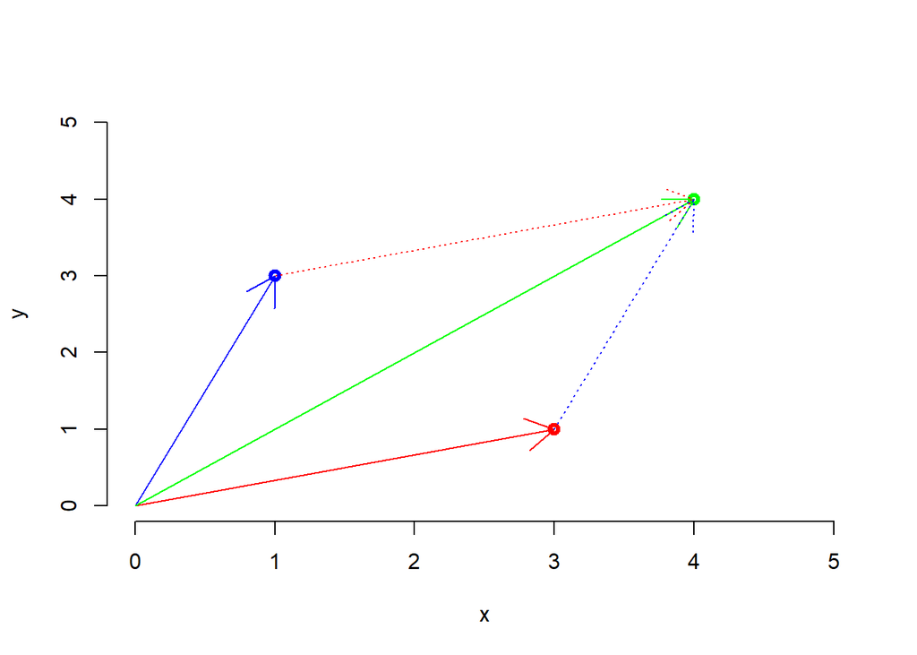

```r
#Suma de vector
plot(3,1, xlim=c(0,5), ylim=c(0,5), xlab="x", ylab="y", lwd=3, col='red', bty='n')
arrows(0,0,3,1,col='red')
points(1,3,lwd=3,col='blue')
arrows(0,0,1,3,col='blue')
points(4,4,lwd=3,col='green')
arrows(0,0,4,4,col='green')
arrows(1,3,4,4,col='red',lty=3)
arrows(3,1,4,4,col='blue',lty=3)
```

**Respuestas:**

**a.** Los vectores base utilizados para diseñar la figura son $(3,1)$ y $(1,3)$

**b.** El vector de color verde es la suma del vector azul y el vector rojo

Realice una modificación al Código, de manera que se en lugar de ilustrar la suma de vectores, se ilustre la resta de los vectores base.

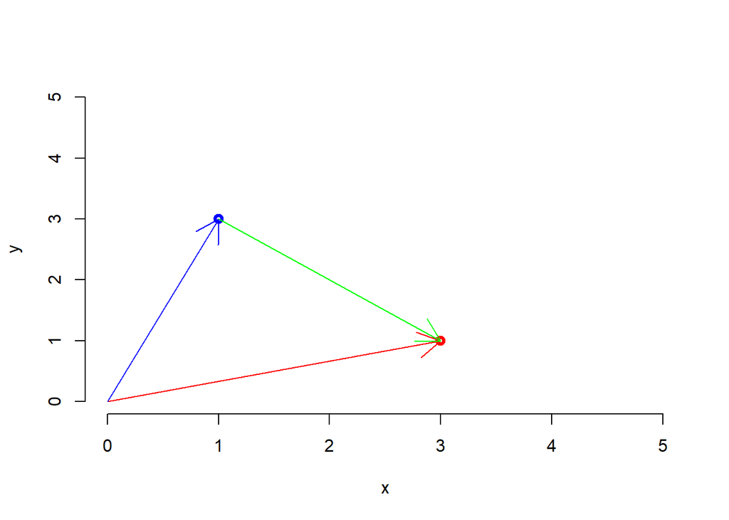

```r
#Resta de vector
plot(3,1, xlim=c(0,5), ylim=c(0,5), xlab="x", ylab="y", lwd=3, col='red', bty='n')
arrows(0,0,3,1,col='red')
points(1,3,lwd=3,col='blue')
arrows(0,0,1,3,col='blue')
arrows(1,3,3,1,col='green')
```

Complete la siguiente tabla, explicando la función de ciertas instrucciones del comando *plot* y *arrows*

| Comando | Explicación |
| --- | --- |
| xlim, ylim | Limites del eje $x$ y el eje $y$ |
| xlab, ylab | Etiqueta del eje $x$ y el eje $y$ |
| lwd | Que tan ancho es la linea |
| lty | El tipo de linea |
| col | El color de la linea |
| bty | El formato del gráfico |